# Lab 2 : AssurExperts INC.

Iheb Jridi

```python
import pandas as pd
import numpy as np
import matplotlib.pyplot as plt
from sklearn.decomposition import PCA
from sklearn.preprocessing import StandardScaler
from sklearn.model_selection import train_test_split , KFold,GridSearchCV
from sklearn.ensemble import RandomForestClassifier
from sklearn.metrics import accuracy_score , precision_score ,f1_score , recall_score ,roc_curve,confusion_matrix,fbeta_score
from imblearn.over_sampling import SMOTE
from sklearn.linear_model import LogisticRegression
from sklearn.feature_selection import SelectKBest,SelectFromModel,RFE,RFECV
import seaborn as sns
from xgboost import XGBClassifier
from sklearn.cluster import KMeans
```

## Importation et découverte des données :

```python
data = pd.read_csv("assur.csv")
```

```python
data.head()
```

|  | Customer_Subtype_see_L0 | Number_of_houses_1_–_10 | Avg_size_household_1_–_6 | Avg_age_see_L1 | Customer_main_type_see_L2 | Roman_catholic_see_L3 | Protestant_... | Other_religion | No_religion | Married | ... | Number_of_private_accident_insurance_policies | Number_of_family_accidents_insurance_policies | Number_of_disability_insurance_policies | Number_of_fire_policies | Number_of_surfboard_policies | Number_of_boat_policies | Number_of_bicycle_policies | Number_of_property_insurance_policies | Number_of_social_security_insurance_policies | CLASS |
| --- | --- | --- | --- | --- | --- | --- | --- | --- | --- | --- | --- | --- | --- | --- | --- | --- | --- | --- | --- | --- | --- |
| 0 | 33 | 1 | 3 | 2 | 8 | 0 | 5 | 1 | 3 | 7 | ... | 0 | 0 | 0 | 1 | 0 | 0 | 0 | 0 | 0 | No |
| 1 | 37 | 1 | 2 | 2 | 8 | 1 | 4 | 1 | 4 | 6 | ... | 0 | 0 | 0 | 1 | 0 | 0 | 0 | 0 | 0 | No |
| 2 | 37 | 1 | 2 | 2 | 8 | 0 | 4 | 2 | 4 | 3 | ... | 0 | 0 | 0 | 1 | 0 | 0 | 0 | 0 | 0 | No |
| 3 | 9 | 1 | 3 | 3 | 3 | 2 | 3 | 2 | 4 | 5 | ... | 0 | 0 | 0 | 1 | 0 | 0 | 0 | 0 | 0 | No |
| 4 | 40 | 1 | 4 | 2 | 10 | 1 | 4 | 1 | 4 | 7 | ... | 0 | 0 | 0 | 1 | 0 | 0 | 0 | 0 | 0 | No |

5 rows × 86 columns

```python
data.columns
```

```
Index(['Customer_Subtype_see_L0', 'Number_of_houses_1_–_10',
       'Avg_size_household_1_–_6', 'Avg_age_see_L1',
       'Customer_main_type_see_L2', 'Roman_catholic_see_L3', 'Protestant_...',
       'Other_religion', 'No_religion', 'Married', 'Living_together',
       'Other_relation', 'Singles', 'Household_without_children',
       'Household_with_children', 'High_level_education',
       'Medium_level_education', 'Lower_level_education', 'High_status',
       'Entrepreneur', 'Farmer', 'Middle_management', 'Skilled_labourers',
       'Unskilled_labourers', 'Social_class_A', 'Social_class_B1',
       'Social_class_B2', 'Social_class_C', 'Social_class_D', 'Rented_house',
       'Home_owners', '1_car', '2_cars', 'No_car', 'National_Health_Service',
       'Private_health_insurance', 'Income_<_30.000', 'Income_30-45.000',
       'Income_45-75.000', 'Income_75-122.000', 'Income_>123.000',
       'Average_income', 'Purchasing_power_class',
       'Contribution_private_third_party_insurance_see_L4',
       'Contribution_third_party_insurance_(firms)_...',
       'Contribution_third_party_insurane_(agriculture)',
       'Contribution_car_policies', 'Contribution_delivery_van_policies',
       'Contribution_motorcycle/scooter_policies',
       'Contribution_lorry_policies', 'Contribution_trailer_policies',
       'Contribution_tractor_policies',
       'Contribution_agricultural_machines_policies',
       'Contribution_moped_policies', 'Contribution_life_insurances',
       'Contribution_private_accident_insurance_policies',
       'Contribution_family_accidents_insurance_policies',
       'Contribution_disability_insurance_policies',
       'Contribution_fire_policies', 'Contribution_surfboard_policies',
       'Contribution_boat_policies', 'Contribution_bicycle_policies',
       'Contribution_property_insurance_policies',
       'Contribution_social_security_insurance_policies',
       'Number_of_private_third_party_insurance_1_-_12',
       'Number_of_third_party_insurance_(firms)_...',
       'Number_of_third_party_insurane_(agriculture)',
       'Number_of_car_policies', 'Number_of_delivery_van_policies',
       'Number_of_motorcycle/scooter_policies', 'Number_of_lorry_policies',
       'Number_of_trailer_policies', 'Number_of_tractor_policies',
       'Number_of_agricultural_machines_policies', 'Number_of_moped_policies',
       'Number_of_life_insurances',
       'Number_of_private_accident_insurance_policies',
       'Number_of_family_accidents_insurance_policies',
       'Number_of_disability_insurance_policies', 'Number_of_fire_policies',
       'Number_of_surfboard_policies', 'Number_of_boat_policies',
       'Number_of_bicycle_policies', 'Number_of_property_insurance_policies',
       'Number_of_social_security_insurance_policies', 'CLASS'],
      dtype='object')
```

## FEATURE SELECTION :

### Correlation entre les variables :

Cette étape a été faite sur R avec la fonction :

```
findCorrelation(mat_cor,cutoff = 0.7)
```

```python
X_dum_cor = pd.read_csv("X_dum_corr.csv")
```

```python
X_dum_cor.head()
```

|  | Number_of_houses_1_â.._10 | Avg_age_see_L1 | Roman_catholic_see_L3 | Other_religion | No_religion | Living_together | Singles | Household_without_children | Household_with_children | High_level_education | ... | Customer_Subtype_see_L0_38 | Customer_Subtype_see_L0_39 | Customer_Subtype_see_L0_40 | Customer_Subtype_see_L0_41 | Customer_main_type_see_L2_1 | Customer_main_type_see_L2_3 | Customer_main_type_see_L2_4 | Customer_main_type_see_L2_5 | Customer_main_type_see_L2_6 | Customer_main_type_see_L2_7 |
| --- | --- | --- | --- | --- | --- | --- | --- | --- | --- | --- | --- | --- | --- | --- | --- | --- | --- | --- | --- | --- | --- |
| 0 | 1 | 2 | 0 | 1 | 3 | 0 | 1 | 2 | 6 | 1 | ... | 0 | 0 | 0 | 0 | 0 | 0 | 0 | 0 | 0 | 0 |
| 1 | 1 | 2 | 1 | 1 | 4 | 2 | 0 | 4 | 5 | 0 | ... | 0 | 0 | 0 | 0 | 0 | 0 | 0 | 0 | 0 | 0 |
| 2 | 1 | 2 | 0 | 2 | 4 | 2 | 4 | 4 | 2 | 0 | ... | 0 | 0 | 0 | 0 | 0 | 0 | 0 | 0 | 0 | 0 |
| 3 | 1 | 3 | 2 | 2 | 4 | 2 | 2 | 3 | 4 | 3 | ... | 0 | 0 | 0 | 0 | 0 | 1 | 0 | 0 | 0 | 0 |
| 4 | 1 | 2 | 1 | 1 | 4 | 1 | 2 | 4 | 4 | 5 | ... | 0 | 0 | 1 | 0 | 0 | 0 | 0 | 0 | 0 | 0 |

5 rows × 99 columns

```python
y = data["CLASS"]
```

### RFE (Feature ranking with recursive feature elimination)

```python
rf = RandomForestClassifier(n_estimators=1000,random_state=0)
rfe = RFE(rf)
rfe.fit(X_dum_cor,y)
rfe.n_features_
X_dum_cor.columns[rfe.get_support(indices=True)]
```

```
Index(['Avg_age_see_L1', 'Roman_catholic_see_L3', 'Other_religion',
       'No_religion', 'Living_together', 'Singles',
       'Household_without_children', 'Household_with_children',
       'High_level_education', 'Medium_level_education', 'High_status',
       'Entrepreneur', 'Farmer', 'Middle_management', 'Skilled_labourers',
       'Unskilled_labourers', 'Social_class_B1', 'Social_class_B2',
       'Social_class_C', 'Social_class_D', 'Rented_house', 'X1_car', 'X2_cars',
       'National_Health_Service', 'Income_._30.000', 'Income_30.45.000',
       'Income_45.75.000', 'Income_75.122.000', 'Income_.123.000',
       'Average_income', 'Purchasing_power_class',
       'Number_of_private_third_party_insurance_1_._12',
       'Number_of_car_policies', 'Number_of_motorcycle.scooter_policies',
       'Number_of_trailer_policies', 'Number_of_tractor_policies',
       'Number_of_moped_policies', 'Number_of_life_insurances',
       'Number_of_family_accidents_insurance_policies',
       'Number_of_fire_policies', 'Number_of_boat_policies',
       'Number_of_bicycle_policies',
       'Number_of_social_security_insurance_policies',
       'Customer_Subtype_see_L0_8', 'Customer_Subtype_see_L0_33',
       'Customer_Subtype_see_L0_36', 'Customer_Subtype_see_L0_38',
       'Customer_main_type_see_L2_1', 'Customer_main_type_see_L2_3'],
      dtype='object')
```

```python
rfe.get_support(indices=True)
```

```
array([ 1,  2,  3,  4,  5,  6,  7,  8,  9, 10, 11, 12, 13, 14, 15, 16, 17,
       18, 19, 20, 21, 22, 23, 24, 25, 26, 27, 28, 29, 30, 31, 32, 35, 37,
       39, 40, 42, 43, 45, 47, 49, 50, 52, 60, 84, 87, 89, 93, 94],
      dtype=int64)
```

```python
X_dum_cor = X_dum_cor[['Avg_age_see_L1', 'Roman_catholic_see_L3', 'Other_religion',
       'No_religion', 'Living_together', 'Singles',
       'Household_without_children', 'Household_with_children',
       'High_level_education', 'Medium_level_education', 'High_status',
       'Entrepreneur', 'Farmer', 'Middle_management', 'Skilled_labourers',
       'Unskilled_labourers', 'Social_class_B1', 'Social_class_B2',
       'Social_class_C', 'Social_class_D', 'Rented_house', 'X1_car', 'X2_cars',
       'National_Health_Service', 'Income_._30.000', 'Income_30.45.000',
       'Income_45.75.000', 'Income_75.122.000', 'Income_.123.000',
       'Average_income', 'Purchasing_power_class',
       'Number_of_private_third_party_insurance_1_._12',
       'Number_of_car_policies', 'Number_of_motorcycle.scooter_policies',
       'Number_of_trailer_policies', 'Number_of_tractor_policies',
       'Number_of_moped_policies', 'Number_of_life_insurances',
       'Number_of_family_accidents_insurance_policies',
       'Number_of_fire_policies', 'Number_of_boat_policies',
       'Number_of_bicycle_policies',
       'Number_of_social_security_insurance_policies',
       'Customer_Subtype_see_L0_8', 'Customer_Subtype_see_L0_33',
       'Customer_Subtype_see_L0_36', 'Customer_Subtype_see_L0_38',
       'Customer_main_type_see_L2_1', 'Customer_main_type_see_L2_3']]
```

```python
rfe.n_features_
```

```
49
```

```python
(rfe.estimator_.feature_importances_ * X_dum_cor.iloc[0,:]).sum()
```

```
1.6890458241004938
```

#### Ici on va multiplier les valeurs de chaque ligne avec le résultat ( coefficient ) du feature importance du RFE pour avoir un score pour chaque individu:

```python
l = []
for i in range(len(X_dum_cor)):
    l.append((rfe.estimator_.feature_importances_ * X_dum_cor.iloc[i,:]).sum())
```

```python
data_score = X_dum_cor.copy()
data_score["score"] = l
data_score["CLASS"] = y
```

```python
#data_score.to_csv("X_dum_scores.csv",index=False)
```

```python
data_score = pd.read_csv("X_dum_scores.csv")
```

```python
data_score[data_score["CLASS"] == "No"].describe()
```

|  | Avg_age_see_L1 | Roman_catholic_see_L3 | Other_religion | No_religion | Living_together | Singles | Household_without_children | Household_with_children | High_level_education | Medium_level_education | ... | Number_of_boat_policies | Number_of_bicycle_policies | Number_of_social_security_insurance_policies | Customer_Subtype_see_L0_8 | Customer_Subtype_see_L0_33 | Customer_Subtype_see_L0_36 | Customer_Subtype_see_L0_38 | Customer_main_type_see_L2_1 | Customer_main_type_see_L2_3 | score |
| --- | --- | --- | --- | --- | --- | --- | --- | --- | --- | --- | --- | --- | --- | --- | --- | --- | --- | --- | --- | --- | --- |
| count | 9236.000000 | 9236.000000 | 9236.000000 | 9236.000000 | 9236.000000 | 9236.000000 | 9236.000000 | 9236.000000 | 9236.000000 | 9236.000000 | ... | 9236.000000 | 9236.000000 | 9236.000000 | 9236.000000 | 9236.000000 | 9236.000000 | 9236.000000 | 9236.000000 | 9236.000000 | 9236.000000 |
| mean | 2.997293 | 0.696838 | 1.048506 | 3.277176 | 0.881009 | 1.911650 | 3.238198 | 4.282482 | 1.449545 | 3.291793 | ... | 0.003465 | 0.030316 | 0.012343 | 0.051321 | 0.143027 | 0.037462 | 0.057492 | 0.095712 | 0.152014 | 1.750741 |
| std | 0.806372 | 1.016440 | 1.009016 | 1.603476 | 0.969610 | 1.788549 | 1.604000 | 1.983254 | 1.623711 | 1.718986 | ... | 0.064053 | 0.203784 | 0.111394 | 0.220663 | 0.350120 | 0.189902 | 0.232794 | 0.294212 | 0.359054 | 0.160954 |
| min | 1.000000 | 0.000000 | 0.000000 | 0.000000 | 0.000000 | 0.000000 | 0.000000 | 0.000000 | 0.000000 | 0.000000 | ... | 0.000000 | 0.000000 | 0.000000 | 0.000000 | 0.000000 | 0.000000 | 0.000000 | 0.000000 | 0.000000 | 1.123627 |
| 25% | 2.000000 | 0.000000 | 0.000000 | 2.000000 | 0.000000 | 0.000000 | 2.000000 | 3.000000 | 0.000000 | 2.000000 | ... | 0.000000 | 0.000000 | 0.000000 | 0.000000 | 0.000000 | 0.000000 | 0.000000 | 0.000000 | 0.000000 | 1.644218 |
| 50% | 3.000000 | 0.000000 | 1.000000 | 3.000000 | 1.000000 | 2.000000 | 3.000000 | 4.000000 | 1.000000 | 3.000000 | ... | 0.000000 | 0.000000 | 0.000000 | 0.000000 | 0.000000 | 0.000000 | 0.000000 | 0.000000 | 0.000000 | 1.751625 |
| 75% | 3.000000 | 1.000000 | 2.000000 | 4.000000 | 1.000000 | 3.000000 | 4.000000 | 6.000000 | 2.000000 | 4.000000 | ... | 0.000000 | 0.000000 | 0.000000 | 0.000000 | 0.000000 | 0.000000 | 0.000000 | 0.000000 | 0.000000 | 1.859489 |
| max | 6.000000 | 9.000000 | 5.000000 | 9.000000 | 7.000000 | 9.000000 | 9.000000 | 9.000000 | 9.000000 | 9.000000 | ... | 2.000000 | 4.000000 | 2.000000 | 1.000000 | 1.000000 | 1.000000 | 1.000000 | 1.000000 | 1.000000 | 2.798056 |

8 rows × 50 columns

```python
data_score[data_score["CLASS"] == "Yes"].describe()
```

|  | Avg_age_see_L1 | Roman_catholic_see_L3 | Other_religion | No_religion | Living_together | Singles | Household_without_children | Household_with_children | High_level_education | Medium_level_education | ... | Number_of_boat_policies | Number_of_bicycle_policies | Number_of_social_security_insurance_policies | Customer_Subtype_see_L0_8 | Customer_Subtype_see_L0_33 | Customer_Subtype_see_L0_36 | Customer_Subtype_see_L0_38 | Customer_main_type_see_L2_1 | Customer_main_type_see_L2_3 | score |
| --- | --- | --- | --- | --- | --- | --- | --- | --- | --- | --- | --- | --- | --- | --- | --- | --- | --- | --- | --- | --- | --- |
| count | 586.000000 | 586.000000 | 586.000000 | 586.000000 | 586.000000 | 586.000000 | 586.000000 | 586.000000 | 586.000000 | 586.000000 | ... | 586.000000 | 586.000000 | 586.000000 | 586.000000 | 586.000000 | 586.000000 | 586.000000 | 586.000000 | 586.000000 | 586.000000 |
| mean | 2.982935 | 0.761092 | 1.075085 | 3.039249 | 0.749147 | 1.503413 | 3.223549 | 4.624573 | 2.035836 | 3.551195 | ... | 0.030717 | 0.049488 | 0.037543 | 0.122867 | 0.136519 | 0.046075 | 0.064846 | 0.127986 | 0.186007 | 1.831729 |
| std | 0.777712 | 0.992754 | 1.044887 | 1.635136 | 0.822883 | 1.577888 | 1.689442 | 1.972203 | 1.881192 | 1.774927 | ... | 0.191472 | 0.279085 | 0.190250 | 0.328565 | 0.343632 | 0.209827 | 0.246465 | 0.334360 | 0.389445 | 0.160551 |
| min | 1.000000 | 0.000000 | 0.000000 | 0.000000 | 0.000000 | 0.000000 | 0.000000 | 0.000000 | 0.000000 | 0.000000 | ... | 0.000000 | 0.000000 | 0.000000 | 0.000000 | 0.000000 | 0.000000 | 0.000000 | 0.000000 | 0.000000 | 1.422564 |
| 25% | 2.000000 | 0.000000 | 0.000000 | 2.000000 | 0.000000 | 0.000000 | 2.000000 | 3.000000 | 0.000000 | 2.000000 | ... | 0.000000 | 0.000000 | 0.000000 | 0.000000 | 0.000000 | 0.000000 | 0.000000 | 0.000000 | 0.000000 | 1.717573 |
| 50% | 3.000000 | 0.000000 | 1.000000 | 3.000000 | 1.000000 | 1.000000 | 3.000000 | 4.000000 | 2.000000 | 4.000000 | ... | 0.000000 | 0.000000 | 0.000000 | 0.000000 | 0.000000 | 0.000000 | 0.000000 | 0.000000 | 0.000000 | 1.837964 |
| 75% | 3.000000 | 1.000000 | 2.000000 | 4.000000 | 1.000000 | 2.000000 | 4.000000 | 6.000000 | 3.000000 | 5.000000 | ... | 0.000000 | 0.000000 | 0.000000 | 0.000000 | 0.000000 | 0.000000 | 0.000000 | 0.000000 | 0.000000 | 1.938449 |
| max | 6.000000 | 7.000000 | 5.000000 | 7.000000 | 4.000000 | 8.000000 | 9.000000 | 9.000000 | 9.000000 | 9.000000 | ... | 2.000000 | 3.000000 | 1.000000 | 1.000000 | 1.000000 | 1.000000 | 1.000000 | 1.000000 | 1.000000 | 2.314255 |

8 rows × 50 columns

## Modèle pour chercher les individus potentiellement interessés :

### Clustering:

On va segmenter les lignes ou CLASS = "No" en 5 segments , puis prendre de chaque segment n lignes pour enfin les fusionner et avoir un échantillon hétérogène et égal au nombre de lignes ou CLASS = "Yes :

```python
dataNo = data_score[data_score["CLASS"] == "No"].drop("CLASS",axis=1)
```

```python
kmeans = KMeans(n_clusters=5, random_state=0)
```

```python
kmeans.fit(dataNo)
clusters = kmeans.predict(dataNo)
dataNo["cluster"] = clusters
dataNo["CLASS"] = data_score[data_score["CLASS"] == "No"]["CLASS"]
```

```python
clustZero = dataNo[dataNo['cluster'] == 0]
clustOne = dataNo[dataNo['cluster'] == 1]
clustTwo = dataNo[dataNo['cluster'] == 2]
clustThree = dataNo[dataNo['cluster'] == 3]
clustFour = dataNo[dataNo['cluster'] == 4]
```

```python
dataNoNew = clustZero.sample(n=118, random_state=0)
dataNoNew = dataNoNew.append(clustOne.sample(n=117, random_state=0))
dataNoNew = dataNoNew.append(clustTwo.sample(n=117, random_state=0))
dataNoNew = dataNoNew.append(clustThree.sample(n=117, random_state=0))
dataNoNew = dataNoNew.append(clustFour.sample(n=117, random_state=0))
```

```python
dataNoNew.shape
```

```
(586, 52)
```

```python
dataYesNoNew = dataNoNew.append(data_score[data_score["CLASS"] == "Yes"])
```

```python
dataYesNoNew.columns
```

```
Index(['Average_income', 'Avg_age_see_L1', 'CLASS',
       'Customer_Subtype_see_L0_33', 'Customer_Subtype_see_L0_36',
       'Customer_Subtype_see_L0_38', 'Customer_Subtype_see_L0_8',
       'Customer_main_type_see_L2_1', 'Customer_main_type_see_L2_3',
       'Entrepreneur', 'Farmer', 'High_level_education', 'High_status',
       'Household_with_children', 'Household_without_children',
       'Income_.123.000', 'Income_._30.000', 'Income_30.45.000',
       'Income_45.75.000', 'Income_75.122.000', 'Living_together',
       'Medium_level_education', 'Middle_management',
       'National_Health_Service', 'No_religion', 'Number_of_bicycle_policies',
       'Number_of_boat_policies', 'Number_of_car_policies',
       'Number_of_family_accidents_insurance_policies',
       'Number_of_fire_policies', 'Number_of_life_insurances',
       'Number_of_moped_policies', 'Number_of_motorcycle.scooter_policies',
       'Number_of_private_third_party_insurance_1_._12',
       'Number_of_social_security_insurance_policies',
       'Number_of_tractor_policies', 'Number_of_trailer_policies',
       'Other_religion', 'Purchasing_power_class', 'Rented_house',
       'Roman_catholic_see_L3', 'Singles', 'Skilled_labourers',
       'Social_class_B1', 'Social_class_B2', 'Social_class_C',
       'Social_class_D', 'Unskilled_labourers', 'X1_car', 'X2_cars', 'cluster',
       'score'],
      dtype='object')
```

```python
X = dataYesNoNew.drop(["CLASS","cluster","score"],axis=1)
```

```python
X.shape
```

```
(1172, 49)
```

```python
y = dataYesNoNew["CLASS"]
```

```python
def print_metrics(y_test,y_pred):
    print("accuracy : ",accuracy_score(y_test,y_pred))
    print("precision : ",precision_score(y_test,y_pred,average='binary',pos_label="Yes"))
    print("recall : ",recall_score(y_test,y_pred,average='binary',pos_label="Yes"))
    print("f1_score : ",f1_score(y_test,y_pred,average='binary',pos_label="Yes"))
    print("fb_score : ",fbeta_score(y_test,y_pred,5,average='binary',pos_label="Yes"))
    print("____________________________")
```

### Entrainer le modèle RandomForest avec le dataset créé :

#### RandomForest :

```python
rf1 = RandomForestClassifier(n_estimators=1000,random_state=0)
```

KFold pour la crossvalidation :

```python
folds = KFold(n_splits=15,shuffle=True,random_state=0)
```

```python
max_a = 0
max_train_i = 0
max_test_i = 0
for train_i , test_i in folds.split(X):
    rf1.fit(X.iloc[train_i],y.iloc[train_i])
    y_pred = rf1.predict(X.iloc[test_i])
    print_metrics(y.iloc[test_i].values,y_pred)
    sc = f1_score(y.iloc[test_i].values,y_pred,average="binary",pos_label="Yes")
    if (max_a < float(sc)):
        max_a = sc
        max_train_i = train_i
        max_test_i = test_i
```

```
accuracy :  0.6329113924050633
precision :  0.6511627906976745
recall :  0.6666666666666666
f1_score :  0.6588235294117646
fb_score :  0.6660567246111619
____________________________
accuracy :  0.6835443037974683
precision :  0.6666666666666666
recall :  0.6842105263157895
f1_score :  0.6753246753246753
fb_score :  0.6835187057633973
____________________________
accuracy :  0.6410256410256411
precision :  0.6944444444444444
recall :  0.5952380952380952
f1_score :  0.6410256410256411
fb_score :  0.5985267034990792
____________________________
accuracy :  0.5769230769230769
precision :  0.6944444444444444
recall :  0.5319148936170213
f1_score :  0.6024096385542169
fb_score :  0.5367464905037158
____________________________
accuracy :  0.717948717948718
precision :  0.6923076923076923
recall :  0.7297297297297297
f1_score :  0.7105263157894737
fb_score :  0.7282157676348548
____________________________
accuracy :  0.5256410256410257
precision :  0.46153846153846156
recall :  0.5294117647058824
f1_score :  0.4931506849315069
fb_score :  0.5264341957255344
____________________________
accuracy :  0.6153846153846154
precision :  0.5384615384615384
recall :  0.6363636363636364
f1_score :  0.5833333333333334
```

[output cut: 35 more lines]

```
f1_score :  0.6588235294117647
fb_score :  0.6001648804616653
____________________________
accuracy :  0.6794871794871795
precision :  0.6666666666666666
recall :  0.5714285714285714
f1_score :  0.6153846153846153
fb_score :  0.574585635359116
____________________________
accuracy :  0.5769230769230769
precision :  0.6428571428571429
recall :  0.6
f1_score :  0.6206896551724138
fb_score :  0.601542416452442
____________________________
```

```python
rf2 = RandomForestClassifier(n_estimators=1000,random_state=0)
rf2 = rf2.fit(X.iloc[max_train_i],y.iloc[max_train_i])
```

```python
X.columns
```

```
Index(['Average_income', 'Avg_age_see_L1', 'Customer_Subtype_see_L0_33',
       'Customer_Subtype_see_L0_36', 'Customer_Subtype_see_L0_38',
       'Customer_Subtype_see_L0_8', 'Customer_main_type_see_L2_1',
       'Customer_main_type_see_L2_3', 'Entrepreneur', 'Farmer',
       'High_level_education', 'High_status', 'Household_with_children',
       'Household_without_children', 'Income_.123.000', 'Income_._30.000',
       'Income_30.45.000', 'Income_45.75.000', 'Income_75.122.000',
       'Living_together', 'Medium_level_education', 'Middle_management',
       'National_Health_Service', 'No_religion', 'Number_of_bicycle_policies',
       'Number_of_boat_policies', 'Number_of_car_policies',
       'Number_of_family_accidents_insurance_policies',
       'Number_of_fire_policies', 'Number_of_life_insurances',
       'Number_of_moped_policies', 'Number_of_motorcycle.scooter_policies',
       'Number_of_private_third_party_insurance_1_._12',
       'Number_of_social_security_insurance_policies',
       'Number_of_tractor_policies', 'Number_of_trailer_policies',
       'Other_religion', 'Purchasing_power_class', 'Rented_house',
       'Roman_catholic_see_L3', 'Singles', 'Skilled_labourers',
       'Social_class_B1', 'Social_class_B2', 'Social_class_C',
       'Social_class_D', 'Unskilled_labourers', 'X1_car', 'X2_cars'],
      dtype='object')
```

```python
y_pred = rf2.predict(data_score[['Average_income', 'Avg_age_see_L1', 'Customer_Subtype_see_L0_33',
       'Customer_Subtype_see_L0_36', 'Customer_Subtype_see_L0_38',
       'Customer_Subtype_see_L0_8', 'Customer_main_type_see_L2_1',
       'Customer_main_type_see_L2_3', 'Entrepreneur', 'Farmer',
       'High_level_education', 'High_status', 'Household_with_children',
       'Household_without_children', 'Income_.123.000', 'Income_._30.000',
       'Income_30.45.000', 'Income_45.75.000', 'Income_75.122.000',
       'Living_together', 'Medium_level_education', 'Middle_management',
       'National_Health_Service', 'No_religion', 'Number_of_bicycle_policies',
       'Number_of_boat_policies', 'Number_of_car_policies',
       'Number_of_family_accidents_insurance_policies',
       'Number_of_fire_policies', 'Number_of_life_insurances',
       'Number_of_moped_policies', 'Number_of_motorcycle.scooter_policies',
       'Number_of_private_third_party_insurance_1_._12',
       'Number_of_social_security_insurance_policies',
       'Number_of_tractor_policies', 'Number_of_trailer_policies',
       'Other_religion', 'Purchasing_power_class', 'Rented_house',
       'Roman_catholic_see_L3', 'Singles', 'Skilled_labourers',
       'Social_class_B1', 'Social_class_B2', 'Social_class_C',
       'Social_class_D', 'Unskilled_labourers', 'X1_car', 'X2_cars']])
```

predict_proba pour avoir la probabilité de chaque ligne d'être un "Yes" :

```python
y_pred_proba = rf2.predict_proba(data_score[['Average_income', 'Avg_age_see_L1', 'Customer_Subtype_see_L0_33',
       'Customer_Subtype_see_L0_36', 'Customer_Subtype_see_L0_38',
       'Customer_Subtype_see_L0_8', 'Customer_main_type_see_L2_1',
       'Customer_main_type_see_L2_3', 'Entrepreneur', 'Farmer',
       'High_level_education', 'High_status', 'Household_with_children',
       'Household_without_children', 'Income_.123.000', 'Income_._30.000',
       'Income_30.45.000', 'Income_45.75.000', 'Income_75.122.000',
       'Living_together', 'Medium_level_education', 'Middle_management',
       'National_Health_Service', 'No_religion', 'Number_of_bicycle_policies',
       'Number_of_boat_policies', 'Number_of_car_policies',
       'Number_of_family_accidents_insurance_policies',
       'Number_of_fire_policies', 'Number_of_life_insurances',
       'Number_of_moped_policies', 'Number_of_motorcycle.scooter_policies',
       'Number_of_private_third_party_insurance_1_._12',
       'Number_of_social_security_insurance_policies',
       'Number_of_tractor_policies', 'Number_of_trailer_policies',
       'Other_religion', 'Purchasing_power_class', 'Rented_house',
       'Roman_catholic_see_L3', 'Singles', 'Skilled_labourers',
       'Social_class_B1', 'Social_class_B2', 'Social_class_C',
       'Social_class_D', 'Unskilled_labourers', 'X1_car', 'X2_cars']])
```

```python
print_metrics(data_score.CLASS,y_pred)
```

```
accuracy :  0.6861128079820811
precision :  0.155776123518059
recall :  0.9641638225255973
f1_score :  0.26821742226441964
fb_score :  0.8037424084915468
____________________________
```

```python
pd.crosstab(data_score.CLASS,y_pred)
```

| col_0 CLASS | No | Yes |
| --- | --- | --- |
| No | 6174 | 3062 |
| Yes | 21 | 565 |

```python
data_score[(y_pred == "No") & (y_pred_proba[:,1] > 0.45) ].shape
```

```
(742, 51)
```

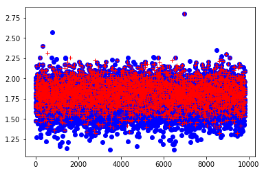

```python
plt.plot(data_score[data_score.CLASS == "No"]["score"],"o",color="blue")
plt.plot(data_score[(y_pred == "Yes")]["score"],"+",color="red")
```

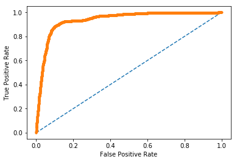

```python
######Random Forest
fpr1, tpr1, thresholds = roc_curve(data_score['CLASS'],y_pred_proba[:,1],pos_label="Yes")
plt.plot([0, 1], [0, 1], linestyle='--')
# plot the roc curve for the model
plt.plot(fpr1, tpr1, marker='.')
# show the plot
plt.xlabel('False Positive Rate')
plt.ylabel('True Positive Rate')
plt.show()
```

#### Support Vector Machine

```python
from sklearn.svm import SVC
svc = SVC(kernel = 'linear', random_state = 1, probability=True)
folds = KFold(n_splits=15,shuffle=True,random_state=0)
```

```python
max_a = 0
max_train_i = 0
max_test_i = 0
for train_i , test_i in folds.split(X):
    svc.fit(X.iloc[train_i],y.iloc[train_i])
    y_pred = svc.predict(X.iloc[test_i])
    print_metrics(y.iloc[test_i].values,y_pred)
    sc = f1_score(y.iloc[test_i].values,y_pred,average="binary",pos_label="Yes")
    if (max_a < float(sc)):
        max_a = sc
        max_train_i = train_i
        max_test_i = test_i
```

```
accuracy :  0.6582278481012658
precision :  0.6923076923076923
recall :  0.6428571428571429
f1_score :  0.6666666666666666
fb_score :  0.6446280991735539
____________________________
accuracy :  0.7215189873417721
precision :  0.7
recall :  0.7368421052631579
f1_score :  0.717948717948718
fb_score :  0.7353535353535353
____________________________
accuracy :  0.7307692307692307
precision :  0.7692307692307693
recall :  0.7142857142857143
f1_score :  0.7407407407407408
fb_score :  0.7162534435261707
____________________________
accuracy :  0.6025641025641025
precision :  0.7
recall :  0.5957446808510638
f1_score :  0.6436781609195402
fb_score :  0.5991769547325102
____________________________
accuracy :  0.782051282051282
precision :  0.75
recall :  0.8108108108108109
f1_score :  0.7792207792207791
fb_score :  0.8082901554404146
____________________________
accuracy :  0.6538461538461539
precision :  0.5897435897435898
recall :  0.6764705882352942
f1_score :  0.6301369863013699
fb_score :  0.672665916760405
____________________________
accuracy :  0.6410256410256411
precision :  0.5641025641025641
recall :  0.6666666666666666
f1_score :  0.611111111111111
```

[output cut: 35 more lines]

```
f1_score :  0.6666666666666666
fb_score :  0.5806451612903226
____________________________
accuracy :  0.6538461538461539
precision :  0.625
recall :  0.5714285714285714
f1_score :  0.5970149253731343
fb_score :  0.5733186328555677
____________________________
accuracy :  0.5897435897435898
precision :  0.6585365853658537
recall :  0.6
f1_score :  0.627906976744186
fb_score :  0.602058319039451
____________________________
```

```python
svc2 = SVC(kernel = 'linear', random_state = 1,probability=True)
svc2 = svc2.fit(X.iloc[max_train_i],y.iloc[max_train_i])
data_score = pd.read_csv('X_dum_scores.csv')
```

```python
y_pred_svm = svc2.predict(data_score[['Average_income', 'Avg_age_see_L1', 'Customer_Subtype_see_L0_33',
       'Customer_Subtype_see_L0_36', 'Customer_Subtype_see_L0_38',
       'Customer_Subtype_see_L0_8', 'Customer_main_type_see_L2_1',
       'Customer_main_type_see_L2_3', 'Entrepreneur', 'Farmer',
       'High_level_education', 'High_status', 'Household_with_children',
       'Household_without_children', 'Income_.123.000', 'Income_._30.000',
       'Income_30.45.000', 'Income_45.75.000', 'Income_75.122.000',
       'Living_together', 'Medium_level_education', 'Middle_management',
       'National_Health_Service', 'No_religion', 'Number_of_bicycle_policies',
       'Number_of_boat_policies', 'Number_of_car_policies',
       'Number_of_family_accidents_insurance_policies',
       'Number_of_fire_policies', 'Number_of_life_insurances',
       'Number_of_moped_policies', 'Number_of_motorcycle.scooter_policies',
       'Number_of_private_third_party_insurance_1_._12',
       'Number_of_social_security_insurance_policies',
       'Number_of_tractor_policies', 'Number_of_trailer_policies',
       'Other_religion', 'Purchasing_power_class', 'Rented_house',
       'Roman_catholic_see_L3', 'Singles', 'Skilled_labourers',
       'Social_class_B1', 'Social_class_B2', 'Social_class_C',
       'Social_class_D', 'Unskilled_labourers', 'X1_car', 'X2_cars']])
```

```python
y_pred_proba_svc = svc2.predict_proba(data_score[['Average_income', 'Avg_age_see_L1', 'Customer_Subtype_see_L0_33',
       'Customer_Subtype_see_L0_36', 'Customer_Subtype_see_L0_38',
       'Customer_Subtype_see_L0_8', 'Customer_main_type_see_L2_1',
       'Customer_main_type_see_L2_3', 'Entrepreneur', 'Farmer',
       'High_level_education', 'High_status', 'Household_with_children',
       'Household_without_children', 'Income_.123.000', 'Income_._30.000',
       'Income_30.45.000', 'Income_45.75.000', 'Income_75.122.000',
       'Living_together', 'Medium_level_education', 'Middle_management',
       'National_Health_Service', 'No_religion', 'Number_of_bicycle_policies',
       'Number_of_boat_policies', 'Number_of_car_policies',
       'Number_of_family_accidents_insurance_policies',
       'Number_of_fire_policies', 'Number_of_life_insurances',
       'Number_of_moped_policies', 'Number_of_motorcycle.scooter_policies',
       'Number_of_private_third_party_insurance_1_._12',
       'Number_of_social_security_insurance_policies',
       'Number_of_tractor_policies', 'Number_of_trailer_policies',
       'Other_religion', 'Purchasing_power_class', 'Rented_house',
       'Roman_catholic_see_L3', 'Singles', 'Skilled_labourers',
       'Social_class_B1', 'Social_class_B2', 'Social_class_C',
       'Social_class_D', 'Unskilled_labourers', 'X1_car', 'X2_cars']])
```

```python
print_metrics(data_score.CLASS,y_pred_svm)
```

```
accuracy :  0.6534310731012014
precision :  0.11227297743533296
recall :  0.6962457337883959
f1_score :  0.1933649289099526
fb_score :  0.580179391817983
____________________________
```

```python
pd.crosstab(data_score.CLASS,y_pred_svm)
```

| col_0 CLASS | No | Yes |
| --- | --- | --- |
| No | 6010 | 3226 |
| Yes | 178 | 408 |

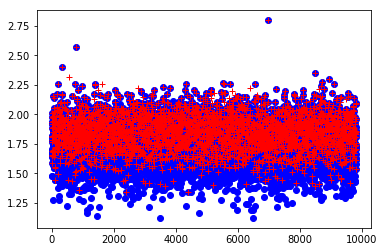

```python
plt.plot(data_score[data_score.CLASS == "No"]["score"],"o",color="blue")
plt.plot(data_score[(y_pred_svm == "Yes")]["score"],"+",color="red")
```

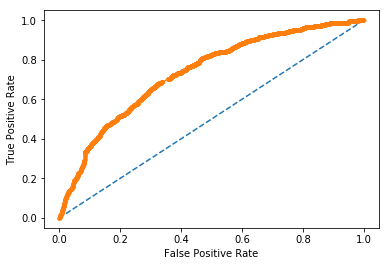

```python
fpr2, tpr2, thresholds = roc_curve(data_score['CLASS'],y_pred_proba_svc[:,1],pos_label="Yes")
plt.plot([0, 1], [0, 1], linestyle='--')
# plot the roc curve for the model
plt.plot(fpr2, tpr2, marker='.')
# show the plot
plt.xlabel('False Positive Rate')
plt.ylabel('True Positive Rate')
plt.show()
```

#### Logistic Regression

```python
from sklearn.linear_model import LogisticRegression
lgr = LogisticRegression(random_state = 1)
```

```python
max_a = 0
max_train_i = 0
max_test_i = 0
for train_i , test_i in folds.split(X):
    lgr.fit(X.iloc[train_i],y.iloc[train_i])
    y_pred = lgr.predict(X.iloc[test_i])
    print_metrics(y.iloc[test_i].values,y_pred)
    sc = f1_score(y.iloc[test_i].values,y_pred,average="binary",pos_label="Yes")
    if (max_a < float(sc)):
        max_a = sc
        max_train_i = train_i
        max_test_i = test_i
```

```
accuracy :  0.6708860759493671
precision :  0.7105263157894737
recall :  0.6428571428571429
f1_score :  0.6749999999999999
fb_score :  0.6452205882352942
____________________________
accuracy :  0.7215189873417721
precision :  0.7
recall :  0.7368421052631579
f1_score :  0.717948717948718
fb_score :  0.7353535353535353
____________________________
accuracy :  0.7435897435897436
precision :  0.7619047619047619
recall :  0.7619047619047619
f1_score :  0.7619047619047619
fb_score :  0.7619047619047619
____________________________
accuracy :  0.6282051282051282
precision :  0.725
recall :  0.6170212765957447
f1_score :  0.6666666666666666
fb_score :  0.6205761316872428
____________________________
accuracy :  0.782051282051282
precision :  0.7631578947368421
recall :  0.7837837837837838
f1_score :  0.7733333333333334
fb_score :  0.7829698857736241
____________________________
accuracy :  0.6538461538461539
precision :  0.5897435897435898
recall :  0.6764705882352942
f1_score :  0.6301369863013699
fb_score :  0.672665916760405
____________________________
accuracy :  0.6666666666666666
precision :  0.6
recall :  0.6363636363636364
f1_score :  0.6176470588235293
fb_score :  0.6348837209302326
____________________________
```

```
accuracy :  0.7435897435897436
precision :  0.65
recall :  0.8125
f1_score :  0.7222222222222223
fb_score :  0.8047619047619048
____________________________
accuracy :  0.6025641025641025
precision :  0.5666666666666667
recall :  0.4857142857142857
f1_score :  0.523076923076923
fb_score :  0.48839779005524864
____________________________
accuracy :  0.6666666666666666
precision :  0.625
recall :  0.6944444444444444
f1_score :  0.6578947368421053
fb_score :  0.6914893617021277
____________________________
accuracy :  0.6923076923076923
precision :  0.75
recall :  0.6818181818181818
f1_score :  0.7142857142857143
fb_score :  0.6842105263157894
____________________________
accuracy :  0.7307692307692307
precision :  0.7368421052631579
recall :  0.717948717948718
f1_score :  0.7272727272727273
fb_score :  0.7186574531095755
____________________________
accuracy :
```

```
 0.6153846153846154
precision :  0.7575757575757576
recall :  0.5319148936170213
f1_score :  0.625
fb_score :  0.5380794701986755
____________________________
accuracy :  0.5897435897435898
precision :  0.5454545454545454
recall :  0.5142857142857142
f1_score :  0.5294117647058822
fb_score :  0.5154185022026431
____________________________
accuracy :  0.6025641025641025
precision :  0.6666666666666666
recall :  0.6222222222222222
f1_score :  0.6436781609195403
fb_score :  0.62382176520994
____________________________
```

```python
lgr2 = LogisticRegression(random_state = 1)
lgr2 = lgr2.fit(X.iloc[max_train_i],y.iloc[max_train_i])
```

```python
y_pred_lgr = lgr2.predict(data_score[['Average_income', 'Avg_age_see_L1', 'Customer_Subtype_see_L0_33',
       'Customer_Subtype_see_L0_36', 'Customer_Subtype_see_L0_38',
       'Customer_Subtype_see_L0_8', 'Customer_main_type_see_L2_1',
       'Customer_main_type_see_L2_3', 'Entrepreneur', 'Farmer',
       'High_level_education', 'High_status', 'Household_with_children',
       'Household_without_children', 'Income_.123.000', 'Income_._30.000',
       'Income_30.45.000', 'Income_45.75.000', 'Income_75.122.000',
       'Living_together', 'Medium_level_education', 'Middle_management',
       'National_Health_Service', 'No_religion', 'Number_of_bicycle_policies',
       'Number_of_boat_policies', 'Number_of_car_policies',
       'Number_of_family_accidents_insurance_policies',
       'Number_of_fire_policies', 'Number_of_life_insurances',
       'Number_of_moped_policies', 'Number_of_motorcycle.scooter_policies',
       'Number_of_private_third_party_insurance_1_._12',
       'Number_of_social_security_insurance_policies',
       'Number_of_tractor_policies', 'Number_of_trailer_policies',
       'Other_religion', 'Purchasing_power_class', 'Rented_house',
       'Roman_catholic_see_L3', 'Singles', 'Skilled_labourers',
       'Social_class_B1', 'Social_class_B2', 'Social_class_C',
       'Social_class_D', 'Unskilled_labourers', 'X1_car', 'X2_cars']])
```

```python
y_pred_proba_lgr = lgr2.predict_proba(data_score[['Average_income', 'Avg_age_see_L1', 'Customer_Subtype_see_L0_33',
       'Customer_Subtype_see_L0_36', 'Customer_Subtype_see_L0_38',
       'Customer_Subtype_see_L0_8', 'Customer_main_type_see_L2_1',
       'Customer_main_type_see_L2_3', 'Entrepreneur', 'Farmer',
       'High_level_education', 'High_status', 'Household_with_children',
       'Household_without_children', 'Income_.123.000', 'Income_._30.000',
       'Income_30.45.000', 'Income_45.75.000', 'Income_75.122.000',
       'Living_together', 'Medium_level_education', 'Middle_management',
       'National_Health_Service', 'No_religion', 'Number_of_bicycle_policies',
       'Number_of_boat_policies', 'Number_of_car_policies',
       'Number_of_family_accidents_insurance_policies',
       'Number_of_fire_policies', 'Number_of_life_insurances',
       'Number_of_moped_policies', 'Number_of_motorcycle.scooter_policies',
       'Number_of_private_third_party_insurance_1_._12',
       'Number_of_social_security_insurance_policies',
       'Number_of_tractor_policies', 'Number_of_trailer_policies',
       'Other_religion', 'Purchasing_power_class', 'Rented_house',
       'Roman_catholic_see_L3', 'Singles', 'Skilled_labourers',
       'Social_class_B1', 'Social_class_B2', 'Social_class_C',
       'Social_class_D', 'Unskilled_labourers', 'X1_car', 'X2_cars']])
```

```python
print_metrics(data_score.CLASS,y_pred_lgr)
```

```
accuracy :  0.651089391162696
precision :  0.11092851273623665
recall :  0.6911262798634812
f1_score :  0.19117299976398397
fb_score :  0.5753783946232446
____________________________
```

```python
pd.crosstab(data_score.CLASS,y_pred_lgr)
```

| col_0 CLASS | No | Yes |
| --- | --- | --- |
| No | 5990 | 3246 |
| Yes | 181 | 405 |

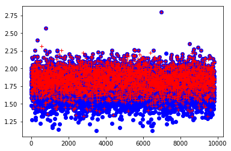

```python
plt.plot(data_score[data_score.CLASS == "No"]["score"],"o",color="blue")
plt.plot(data_score[(y_pred_lgr == "Yes")]["score"],"+",color="red")
```

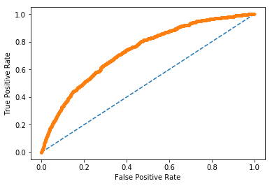

```python
fpr3, tpr3, thresholds = roc_curve(data_score['CLASS'],y_pred_proba_lgr[:,1],pos_label="Yes")
plt.plot([0, 1], [0, 1], linestyle='--')
# plot the roc curve for the model
plt.plot(fpr3, tpr3, marker='.')
# show the plot
plt.xlabel('False Positive Rate')
plt.ylabel('True Positive Rate')
plt.show()
```

#### K-Nearest Neighbors

```python
from sklearn.neighbors import KNeighborsClassifier
knn = KNeighborsClassifier(n_neighbors = 5, metric = 'minkowski', p = 2)
```

```python
max_a = 0
max_train_i = 0
max_test_i = 0
for train_i , test_i in folds.split(X):
    knn.fit(X.iloc[train_i],y.iloc[train_i])
    y_pred = knn.predict(X.iloc[test_i])
    print_metrics(y.iloc[test_i].values,y_pred)
    sc = f1_score(y.iloc[test_i].values,y_pred,average="binary",pos_label="Yes")
    if (max_a < float(sc)):
        max_a = sc
        max_train_i = train_i
        max_test_i = test_i
```

```
accuracy :  0.6075949367088608
precision :  0.627906976744186
recall :  0.6428571428571429
f1_score :  0.6352941176470588
fb_score :  0.6422689844464776
____________________________
accuracy :  0.5443037974683544
precision :  0.5238095238095238
recall :  0.5789473684210527
f1_score :  0.5500000000000002
fb_score :  0.5766129032258064
____________________________
accuracy :  0.6153846153846154
precision :  0.6578947368421053
recall :  0.5952380952380952
f1_score :  0.625
fb_score :  0.5974264705882353
____________________________
accuracy :  0.5256410256410257
precision :  0.6190476190476191
recall :  0.5531914893617021
f1_score :  0.5842696629213483
fb_score :  0.5554642563681184
____________________________
accuracy :  0.6410256410256411
precision :  0.6153846153846154
recall :  0.6486486486486487
f1_score :  0.631578947368421
fb_score :  0.6473029045643154
____________________________
accuracy :  0.5384615384615384
precision :  0.4782608695652174
recall :  0.6470588235294118
f1_score :  0.55
fb_score :  0.6383928571428571
____________________________
accuracy :  0.6153846153846154
precision :  0.5405405405405406
recall :  0.6060606060606061
f1_score :  0.5714285714285714
```

[output cut: 35 more lines]

```
f1_score :  0.6363636363636364
fb_score :  0.5986842105263158
____________________________
accuracy :  0.5641025641025641
precision :  0.5116279069767442
recall :  0.6285714285714286
f1_score :  0.5641025641025641
fb_score :  0.6230936819172114
____________________________
accuracy :  0.5641025641025641
precision :  0.6341463414634146
recall :  0.5777777777777777
f1_score :  0.6046511627906976
fb_score :  0.5797598627787307
____________________________
```

```python
knn2 = KNeighborsClassifier(n_neighbors = 5, metric = 'minkowski', p = 2)
knn2 = knn2.fit(X.iloc[max_train_i],y.iloc[max_train_i])
```

```python
y_pred_knn = knn2.predict(data_score[['Average_income', 'Avg_age_see_L1', 'Customer_Subtype_see_L0_33',
       'Customer_Subtype_see_L0_36', 'Customer_Subtype_see_L0_38',
       'Customer_Subtype_see_L0_8', 'Customer_main_type_see_L2_1',
       'Customer_main_type_see_L2_3', 'Entrepreneur', 'Farmer',
       'High_level_education', 'High_status', 'Household_with_children',
       'Household_without_children', 'Income_.123.000', 'Income_._30.000',
       'Income_30.45.000', 'Income_45.75.000', 'Income_75.122.000',
       'Living_together', 'Medium_level_education', 'Middle_management',
       'National_Health_Service', 'No_religion', 'Number_of_bicycle_policies',
       'Number_of_boat_policies', 'Number_of_car_policies',
       'Number_of_family_accidents_insurance_policies',
       'Number_of_fire_policies', 'Number_of_life_insurances',
       'Number_of_moped_policies', 'Number_of_motorcycle.scooter_policies',
       'Number_of_private_third_party_insurance_1_._12',
       'Number_of_social_security_insurance_policies',
       'Number_of_tractor_policies', 'Number_of_trailer_policies',
       'Other_religion', 'Purchasing_power_class', 'Rented_house',
       'Roman_catholic_see_L3', 'Singles', 'Skilled_labourers',
       'Social_class_B1', 'Social_class_B2', 'Social_class_C',
       'Social_class_D', 'Unskilled_labourers', 'X1_car', 'X2_cars']])
```

```python
y_pred_proba_knn = knn2.predict_proba(data_score[['Average_income', 'Avg_age_see_L1', 'Customer_Subtype_see_L0_33',
       'Customer_Subtype_see_L0_36', 'Customer_Subtype_see_L0_38',
       'Customer_Subtype_see_L0_8', 'Customer_main_type_see_L2_1',
       'Customer_main_type_see_L2_3', 'Entrepreneur', 'Farmer',
       'High_level_education', 'High_status', 'Household_with_children',
       'Household_without_children', 'Income_.123.000', 'Income_._30.000',
       'Income_30.45.000', 'Income_45.75.000', 'Income_75.122.000',
       'Living_together', 'Medium_level_education', 'Middle_management',
       'National_Health_Service', 'No_religion', 'Number_of_bicycle_policies',
       'Number_of_boat_policies', 'Number_of_car_policies',
       'Number_of_family_accidents_insurance_policies',
       'Number_of_fire_policies', 'Number_of_life_insurances',
       'Number_of_moped_policies', 'Number_of_motorcycle.scooter_policies',
       'Number_of_private_third_party_insurance_1_._12',
       'Number_of_social_security_insurance_policies',
       'Number_of_tractor_policies', 'Number_of_trailer_policies',
       'Other_religion', 'Purchasing_power_class', 'Rented_house',
       'Roman_catholic_see_L3', 'Singles', 'Skilled_labourers',
       'Social_class_B1', 'Social_class_B2', 'Social_class_C',
       'Social_class_D', 'Unskilled_labourers', 'X1_car', 'X2_cars']])
```

```python
print_metrics(data_score.CLASS,y_pred_knn)
```

```
accuracy :  0.569232335573203
precision :  0.09723756906077348
recall :  0.7508532423208191
f1_score :  0.17217765603600077
fb_score :  0.5966101694915253
____________________________
```

```python
pd.crosstab(data_score.CLASS,y_pred_knn)
```

| col_0 CLASS | No | Yes |
| --- | --- | --- |
| No | 5151 | 4085 |
| Yes | 146 | 440 |

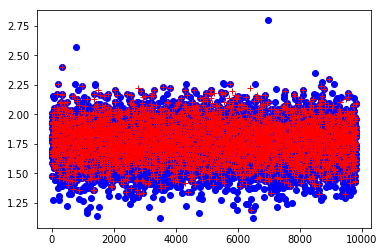

```python
plt.plot(data_score[data_score.CLASS == "No"]["score"],"o",color="blue")
plt.plot(data_score[(y_pred_knn == "Yes")]["score"],"+",color="red")
```

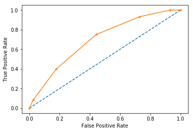

```python
fpr4, tpr4, thresholds = roc_curve(data_score['CLASS'],y_pred_proba_knn[:,1],pos_label="Yes")
plt.plot([0, 1], [0, 1], linestyle='--')
# plot the roc curve for the model
plt.plot(fpr4, tpr4, marker='.')
# show the plot
plt.xlabel('False Positive Rate')
plt.ylabel('True Positive Rate')
plt.show()
```

### Courbes ROC

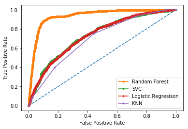

```python
plt.plot([0, 1], [0, 1], linestyle='--')
plt.plot(fpr1, tpr1, marker='.' , label='Random Forest')
plt.plot(fpr2, tpr2, marker='.' , label='SVC')
plt.plot(fpr3, tpr3, marker='.',label='Logistic Regresison')
plt.plot(fpr4, tpr4, marker='.',label='KNN')
plt.xlabel('False Positive Rate')
plt.ylabel('True Positive Rate')
plt.legend()
plt.show()
```

```python
#data_score[(data_score.CLASS == "No") & (data_score["score"]<1.9) & (data_score["score"]>1.8) & (y_pred_proba[:,1] > 0.45)].shape
```

```python
data_score[(data_score.CLASS == "No") & (y_pred == "Yes") & (data_score["score"]>1.75) & (y_pred_proba[:,1] > 0.45)].shape
```

```
(2057, 51)
```

```python
#potentiel = data_score[(data_score.CLASS == "No") & (y_pred == "Yes") & (data_score["score"]>1.75) & (y_pred_proba[:,1] > 0.45)]
```

```python
yes = data_score[(data_score.CLASS == "Yes")]
```

```python
data_sc = data_score.copy()
```

### Combiner les deux scores ; predict_proba et le score calculé auparavant :

```python
data_sc["score_comb"] = data_score["score"]*y_pred_proba[:,1]
```

```python
data_sc[data_sc.CLASS == "Yes"].describe()
```

|  | Avg_age_see_L1 | Roman_catholic_see_L3 | Other_religion | No_religion | Living_together | Singles | Household_without_children | Household_with_children | High_level_education | Medium_level_education | ... | Number_of_bicycle_policies | Number_of_social_security_insurance_policies | Customer_Subtype_see_L0_8 | Customer_Subtype_see_L0_33 | Customer_Subtype_see_L0_36 | Customer_Subtype_see_L0_38 | Customer_main_type_see_L2_1 | Customer_main_type_see_L2_3 | score | score_comb |
| --- | --- | --- | --- | --- | --- | --- | --- | --- | --- | --- | --- | --- | --- | --- | --- | --- | --- | --- | --- | --- | --- |
| count | 586.000000 | 586.000000 | 586.000000 | 586.000000 | 586.000000 | 586.000000 | 586.000000 | 586.000000 | 586.000000 | 586.000000 | ... | 586.000000 | 586.000000 | 586.000000 | 586.000000 | 586.000000 | 586.000000 | 586.000000 | 586.000000 | 586.000000 | 586.000000 |
| mean | 2.982935 | 0.761092 | 1.075085 | 3.039249 | 0.749147 | 1.503413 | 3.223549 | 4.624573 | 2.035836 | 3.551195 | ... | 0.049488 | 0.037543 | 0.122867 | 0.136519 | 0.046075 | 0.064846 | 0.127986 | 0.186007 | 1.831729 | 1.495448 |
| std | 0.777712 | 0.992754 | 1.044887 | 1.635136 | 0.822883 | 1.577888 | 1.689442 | 1.972203 | 1.881192 | 1.774927 | ... | 0.279085 | 0.190250 | 0.328565 | 0.343632 | 0.209827 | 0.246465 | 0.334360 | 0.389445 | 0.160551 | 0.294644 |
| min | 1.000000 | 0.000000 | 0.000000 | 0.000000 | 0.000000 | 0.000000 | 0.000000 | 0.000000 | 0.000000 | 0.000000 | ... | 0.000000 | 0.000000 | 0.000000 | 0.000000 | 0.000000 | 0.000000 | 0.000000 | 0.000000 | 1.422564 | 0.113189 |
| 25% | 2.000000 | 0.000000 | 0.000000 | 2.000000 | 0.000000 | 0.000000 | 2.000000 | 3.000000 | 0.000000 | 2.000000 | ... | 0.000000 | 0.000000 | 0.000000 | 0.000000 | 0.000000 | 0.000000 | 0.000000 | 0.000000 | 1.717573 | 1.331086 |
| 50% | 3.000000 | 0.000000 | 1.000000 | 3.000000 | 1.000000 | 1.000000 | 3.000000 | 4.000000 | 2.000000 | 4.000000 | ... | 0.000000 | 0.000000 | 0.000000 | 0.000000 | 0.000000 | 0.000000 | 0.000000 | 0.000000 | 1.837964 | 1.515578 |
| 75% | 3.000000 | 1.000000 | 2.000000 | 4.000000 | 1.000000 | 2.000000 | 4.000000 | 6.000000 | 3.000000 | 5.000000 | ... | 0.000000 | 0.000000 | 0.000000 | 0.000000 | 0.000000 | 0.000000 | 0.000000 | 0.000000 | 1.938449 | 1.687393 |
| max | 6.000000 | 7.000000 | 5.000000 | 7.000000 | 4.000000 | 8.000000 | 9.000000 | 9.000000 | 9.000000 | 9.000000 | ... | 3.000000 | 1.000000 | 1.000000 | 1.000000 | 1.000000 | 1.000000 | 1.000000 | 1.000000 | 2.314255 | 2.162923 |

8 rows × 51 columns

```python
#data_sc.to_csv("fn_score.csv",index=False)
data_sc = pd.read_csv("fn_score.csv")
```

#### Graphe des scores des "Yes" et "No"

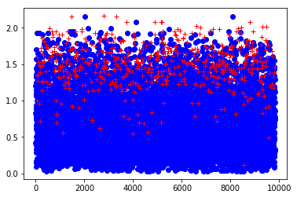

```python
plt.plot(data_sc[data_sc.CLASS == "No"]["score_comb"],"o",color="blue")
plt.plot(data_sc[data_sc.CLASS == "Yes"]["score_comb"],"+",color="red")
```

### Extraction des clients potentiels ( Ceux qui avait "No" et que le modèle a prédit qu'ils ont "Yes" avec un seuil en score ) :

```python
potentiel = data_sc[(data_sc.CLASS == "No") & (y_pred == "Yes") & (data_sc["score_comb"]>1.05)]
```

```python
no = data_score.drop(yes.index,axis=0).drop(potentiel.index,axis=0)
```

```python
yesPotentiel = potentiel.append(yes)
```

```python
yesPotentiel.head()
```

|  | Average_income | Avg_age_see_L1 | CLASS | Customer_Subtype_see_L0_33 | Customer_Subtype_see_L0_36 | Customer_Subtype_see_L0_38 | Customer_Subtype_see_L0_8 | Customer_main_type_see_L2_1 | Customer_main_type_see_L2_3 | Entrepreneur | ... | Skilled_labourers | Social_class_B1 | Social_class_B2 | Social_class_C | Social_class_D | Unskilled_labourers | X1_car | X2_cars | score | score_comb |
| --- | --- | --- | --- | --- | --- | --- | --- | --- | --- | --- | --- | --- | --- | --- | --- | --- | --- | --- | --- | --- | --- |
| 0 | 4 | 2 | No | 1 | 0 | 0 | 0 | 0 | 0 | 0 | ... | 5 | 1 | 2 | 6 | 1 | 2 | 8 | 0 | 1.689046 | 1.200079 |
| 3 | 4 | 3 | No | 0 | 0 | 0 | 0 | 0 | 1 | 0 | ... | 1 | 2 | 1 | 4 | 0 | 2 | 9 | 0 | 1.933423 | 1.249728 |
| 8 | 2 | 4 | No | 1 | 0 | 0 | 0 | 0 | 0 | 1 | ... | 8 | 1 | 0 | 8 | 1 | 1 | 5 | 2 | 1.813446 | 1.348990 |
| 10 | 8 | 3 | No | 0 | 0 | 0 | 0 | 0 | 1 | 0 | ... | 0 | 0 | 6 | 0 | 0 | 0 | 6 | 2 | 1.787684 | 1.066460 |
| 12 | 3 | 3 | No | 1 | 0 | 0 | 0 | 0 | 0 | 1 | ... | 2 | 2 | 2 | 5 | 1 | 4 | 6 | 1 | 1.812978 | 1.701178 |

5 rows × 52 columns

## Classement des clients potentiels :

```python
potentiel.sort_values(by="score_comb",ascending=False).head(20)
```

|  | Avg_age_see_L1 | Roman_catholic_see_L3 | Other_religion | No_religion | Living_together | Singles | Household_without_children | Household_with_children | High_level_education | Medium_level_education | ... | Number_of_social_security_insurance_policies | Customer_Subtype_see_L0_8 | Customer_Subtype_see_L0_33 | Customer_Subtype_see_L0_36 | Customer_Subtype_see_L0_38 | Customer_main_type_see_L2_1 | Customer_main_type_see_L2_3 | score | CLASS | score_comb |
| --- | --- | --- | --- | --- | --- | --- | --- | --- | --- | --- | --- | --- | --- | --- | --- | --- | --- | --- | --- | --- | --- |
| 8100 | 3 | 1 | 2 | 3 | 1 | 1 | 3 | 6 | 1 | 7 | ... | 0 | 0 | 0 | 0 | 0 | 0 | 1 | 2.209688 | No | 2.158423 |
| 2029 | 3 | 1 | 2 | 3 | 1 | 1 | 3 | 6 | 1 | 7 | ... | 0 | 0 | 0 | 0 | 0 | 0 | 1 | 2.209688 | No | 2.158423 |
| 4102 | 2 | 2 | 2 | 2 | 0 | 0 | 0 | 8 | 2 | 4 | ... | 0 | 0 | 0 | 0 | 0 | 0 | 1 | 2.094216 | No | 2.073971 |
| 3094 | 2 | 0 | 2 | 0 | 2 | 0 | 6 | 3 | 2 | 7 | ... | 0 | 0 | 0 | 0 | 0 | 0 | 0 | 2.046699 | No | 1.995668 |
| 2147 | 2 | 0 | 2 | 0 | 2 | 0 | 6 | 3 | 2 | 7 | ... | 0 | 0 | 0 | 0 | 0 | 0 | 0 | 2.046699 | No | 1.995668 |
| 5475 | 4 | 1 | 2 | 4 | 2 | 0 | 6 | 3 | 6 | 3 | ... | 0 | 1 | 0 | 0 | 0 | 0 | 0 | 2.033093 | No | 1.979216 |
| 1406 | 2 | 0 | 2 | 0 | 2 | 0 | 6 | 3 | 2 | 7 | ... | 0 | 0 | 0 | 0 | 0 | 0 | 1 | 2.015555 | No | 1.955088 |
| 1540 | 2 | 0 | 0 | 7 | 0 | 0 | 0 | 9 | 0 | 3 | ... | 0 | 0 | 0 | 0 | 0 | 0 | 1 | 2.161412 | No | 1.954997 |
| 1524 | 2 | 0 | 0 | 7 | 0 | 0 | 0 | 9 | 0 | 3 | ... | 0 | 0 | 0 | 0 | 0 | 0 | 1 | 1.989668 | No | 1.949875 |
| 7934 | 2 | 2 | 2 | 4 | 0 | 0 | 2 | 7 | 2 | 7 | ... | 0 | 1 | 0 | 0 | 0 | 0 | 0 | 1.991968 | No | 1.944327 |
| 2651 | 2 | 0 | 2 | 0 | 2 | 0 | 6 | 3 | 2 | 7 | ... | 0 | 0 | 0 | 0 | 0 | 0 | 0 | 1.993192 | No | 1.938180 |
| 8409 | 2 | 0 | 2 | 0 | 2 | 0 | 6 | 3 | 2 | 7 | ... | 1 | 1 | 0 | 0 | 0 | 0 | 0 | 2.012423 | No | 1.937273 |
| 36 | 2 | 0 | 2 | 0 | 2 | 0 | 6 | 3 | 2 | 7 | ... | 0 | 0 | 0 | 0 | 0 | 0 | 0 | 1.966022 | No | 1.933386 |
| 7173 | 3 | 5 | 1 | 1 | 1 | 1 | 1 | 8 | 1 | 5 | ... | 0 | 0 | 0 | 0 | 0 | 0 | 1 | 2.043491 | No | 1.932461 |
| 496 | 3 | 1 | 1 | 3 | 1 | 0 | 2 | 7 | 3 | 4 | ... | 0 | 1 | 0 | 0 | 0 | 0 | 0 | 2.032233 | No | 1.929267 |
| 3755 | 3 | 5 | 1 | 1 | 1 | 1 | 1 | 8 | 1 | 5 | ... | 0 | 0 | 0 | 0 | 0 | 0 | 1 | 2.023492 | No | 1.925690 |
| 156 | 3 | 5 | 1 | 1 | 1 | 1 | 1 | 8 | 1 | 5 | ... | 0 | 0 | 0 | 0 | 0 | 0 | 1 | 2.023492 | No | 1.925690 |
| 5244 | 3 | 5 | 1 | 1 | 1 | 1 | 1 | 8 | 1 | 5 | ... | 0 | 0 | 0 | 0 | 0 | 0 | 1 | 2.023492 | No | 1.925690 |
| 5106 | 3 | 5 | 1 | 1 | 1 | 1 | 1 | 8 | 1 | 5 | ... | 0 | 0 | 0 | 0 | 0 | 0 | 1 | 2.062904 | No | 1.921939 |
| 4182 | 3 | 1 | 1 | 2 | 1 | 2 | 3 | 5 | 1 | 7 | ... | 0 | 0 | 0 | 0 | 0 | 0 | 1 | 2.024899 | No | 1.918592 |

20 rows × 52 columns

```python
potentiel.sort_values(by="score_comb",ascending=False).index
```

```
Int64Index([8100, 2029, 4102, 3094, 2147, 5475, 1406, 1540, 1524, 7934,
            ...
            8524, 2146, 5853, 8095, 2068, 7171, 6233, 2216, 2416, 4769],
           dtype='int64', length=2032)
```

## Comparaisons entre les "Yes" , "No" et "Potentiel" :

### Average Age :

```
1: 20-30 years
6: 70-80 years
```

Disent "No" principalement

```
Text(0.5,1,'No')
```

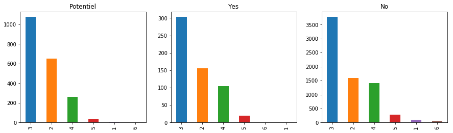

```python
fig, (ax1,ax2,ax3) = plt.subplots(1,3, figsize=(15,4))
potentiel["Avg_age_see_L1"].value_counts().plot(kind="bar",ax=ax1)
ax1.set_title("Potentiel")
yes["Avg_age_see_L1"].value_counts().plot(kind="bar",ax=ax2)
ax2.set_title("Yes")
no["Avg_age_see_L1"].value_counts().plot(kind="bar",ax=ax3)
ax3.set_title("No")
```

### Number of houses :

Ceux qui ont plus que 3 maisons disent "No" principalement

```
Text(0.5,1,'No')
```

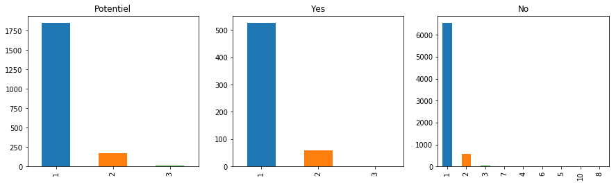

```python
fig, (ax1,ax2,ax3) = plt.subplots(1,3, figsize=(15,4))
data.iloc[potentiel.index,:]["Number_of_houses_1_–_10"].value_counts().plot(kind="bar",ax=ax1)
ax1.set_title("Potentiel")
data.iloc[yes.index,:]["Number_of_houses_1_–_10"].value_counts().plot(kind="bar",ax=ax2)
ax2.set_title("Yes")
data.iloc[no.index,:]["Number_of_houses_1_–_10"].value_counts().plot(kind="bar",ax=ax3)
ax3.set_title("No")
```

### Customer MainType :

```
4: Career Loners
```

Ne disent que "No" principalement

```
Text(0.5,1,'No')
```

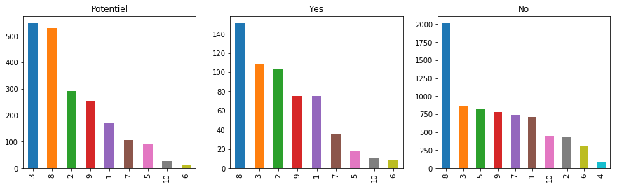

```python
fig, (ax1,ax2,ax3) = plt.subplots(1,3, figsize=(15,4))
data.iloc[potentiel.index,:]["Customer_main_type_see_L2"].value_counts().plot(kind="bar",ax=ax1)
ax1.set_title("Potentiel")
data.iloc[yes.index,:]["Customer_main_type_see_L2"].value_counts().plot(kind="bar",ax=ax2)
ax2.set_title("Yes")
data.iloc[no.index,:]["Customer_main_type_see_L2"].value_counts().plot(kind="bar",ax=ax3)
ax3.set_title("No")
```

### Average Income :

```
2: 11 - 23%
3: 24 - 36%
```

La plupart d'eux ont dit "No"

```
Text(0.5,1,'No')
```

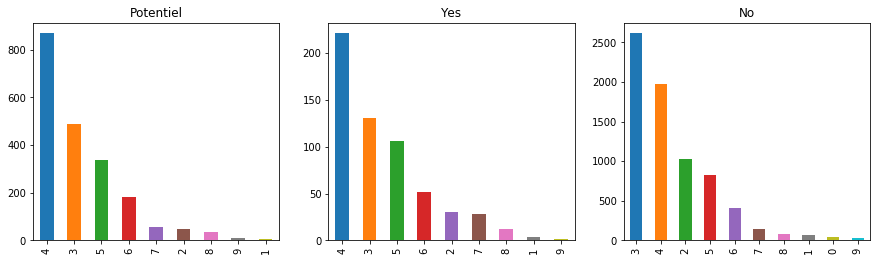

```python
fig, (ax1,ax2,ax3) = plt.subplots(1,3, figsize=(15,4))
potentiel["Average_income"].value_counts().plot(kind="bar",ax=ax1)
ax1.set_title("Potentiel")
yes["Average_income"].value_counts().plot(kind="bar",ax=ax2)
ax2.set_title("Yes")
no["Average_income"].value_counts().plot(kind="bar",ax=ax3)
ax3.set_title("No")
```

### Farmer :

```
6: 63 - 75%
7: 76 - 88%
8: 89 - 99%
9: 100%
```

Ont dit "No"

```
Text(0.5,1,'No')
```

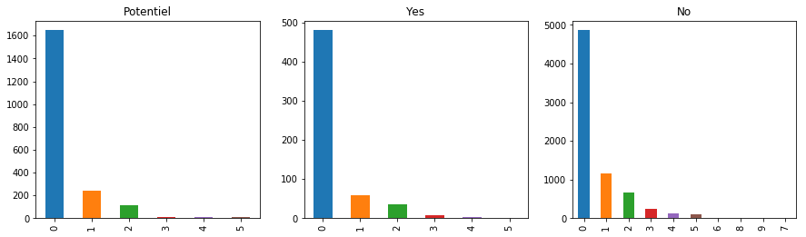

```python
fig, (ax1,ax2,ax3) = plt.subplots(1,3, figsize=(15,4))
potentiel["Farmer"].value_counts().plot(kind="bar",ax=ax1)
ax1.set_title("Potentiel")
yes["Farmer"].value_counts().plot(kind="bar",ax=ax2)
ax2.set_title("Yes")
no["Farmer"].value_counts().plot(kind="bar",ax=ax3)
ax3.set_title("No")
```

### Income < 30.000 :

```
3: 24 - 36%
4: 37 - 49%
5: 50 - 62%
6: 63 - 75%
7: 76 - 88%
8: 89 - 99%
9: 100%
```

Ont dit souvent "No"

```
Text(0.5,1,'No')
```

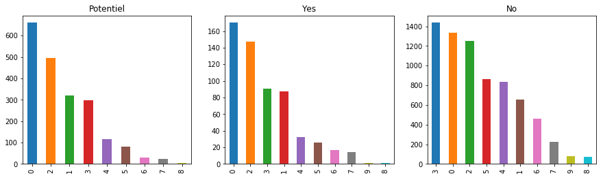

```python
fig, (ax1,ax2,ax3) = plt.subplots(1,3, figsize=(15,4))
potentiel["Income_._30.000"].value_counts().plot(kind="bar",ax=ax1)
ax1.set_title("Potentiel")
yes["Income_._30.000"].value_counts().plot(kind="bar",ax=ax2)
ax2.set_title("Yes")
no["Income_._30.000"].value_counts().plot(kind="bar",ax=ax3)
ax3.set_title("No")
```

### Number_of_car_policies :

```
0: 0
4: 200 - 499
5: 500 - 999
6: 1000 - 4999
```

Ont dit "No" principalement

```
Text(0.5,1,'No')
```

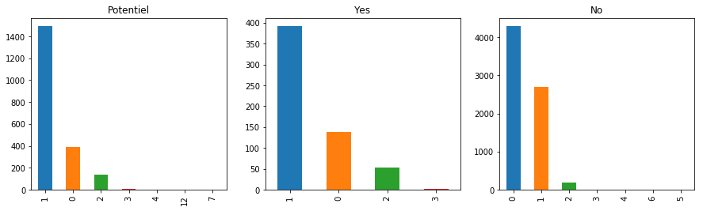

```python
fig, (ax1,ax2,ax3) = plt.subplots(1,3, figsize=(15,4))
potentiel["Number_of_car_policies"].value_counts().plot(kind="bar",ax=ax1)
ax1.set_title("Potentiel")
yes["Number_of_car_policies"].value_counts().plot(kind="bar",ax=ax2)
ax2.set_title("Yes")
no["Number_of_car_policies"].value_counts().plot(kind="bar",ax=ax3)
ax3.set_title("No")
```

### Number_of_boat_policies :

```
1: 1 - 49
```

Ont dit "Yes"

```
Text(0.5,1,'No')
```

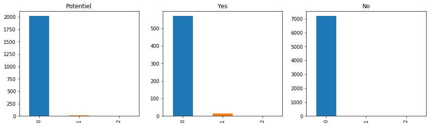

```python
fig, (ax1,ax2,ax3) = plt.subplots(1,3, figsize=(15,4))
potentiel["Number_of_boat_policies"].value_counts().plot(kind="bar",ax=ax1)
ax1.set_title("Potentiel")
yes["Number_of_boat_policies"].value_counts().plot(kind="bar",ax=ax2)
ax2.set_title("Yes")
no["Number_of_boat_policies"].value_counts().plot(kind="bar",ax=ax3)
ax3.set_title("No")
```

### Number of fire policies :

```
0: 0
5: 500 - 999
6: 1000 - 4999
7: 5000 - 9999
```

Le nombre de 0 est élevé en "No"

```
Text(0.5,1,'No')
```

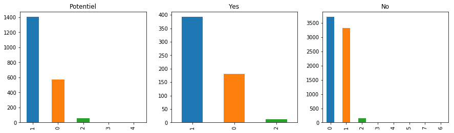

```python
fig, (ax1,ax2,ax3) = plt.subplots(1,3, figsize=(15,4))
potentiel["Number_of_fire_policies"].value_counts().plot(kind="bar",ax=ax1)
ax1.set_title("Potentiel")
yes["Number_of_fire_policies"].value_counts().plot(kind="bar",ax=ax2)
ax2.set_title("Yes")
no["Number_of_fire_policies"].value_counts().plot(kind="bar",ax=ax3)
ax3.set_title("No")
```

### 1 Car :

```
0: 0
1: 1 - 49
```

Ont dit "No"

```
Text(0.5,1,'No')
```

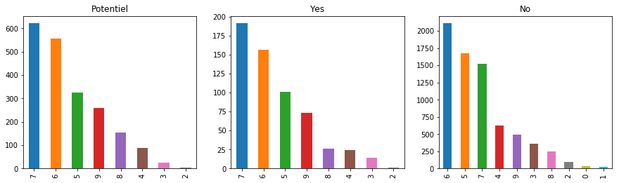

```python
fig, (ax1,ax2,ax3) = plt.subplots(1,3, figsize=(15,4))
potentiel["X1_car"].value_counts().plot(kind="bar",ax=ax1)
ax1.set_title("Potentiel")
yes["X1_car"].value_counts().plot(kind="bar",ax=ax2)
ax2.set_title("Yes")
no["X1_car"].value_counts().plot(kind="bar",ax=ax3)
ax3.set_title("No")
```

### Rented house :

```
8: 10,000 - 19,999
9: >= 20,000
```

Ont dit "No" souvent

```
Text(0.5,1,'No')
```

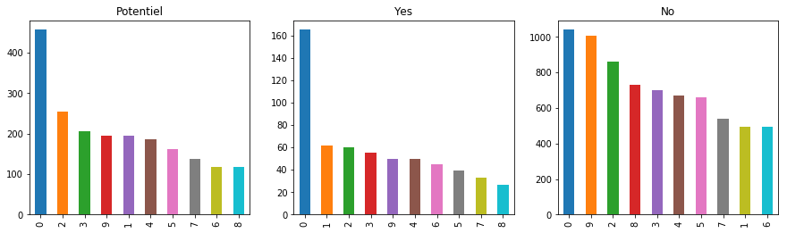

```python
fig, (ax1,ax2,ax3) = plt.subplots(1,3, figsize=(15,4))
data.iloc[potentiel.index,:]["Rented_house"].value_counts().plot(kind="bar",ax=ax1)
ax1.set_title("Potentiel")
data.iloc[yes.index,:]["Rented_house"].value_counts().plot(kind="bar",ax=ax2)
ax2.set_title("Yes")
data.iloc[no.index,:]["Rented_house"].value_counts().plot(kind="bar",ax=ax3)
ax3.set_title("No")
```

## Segments des clients actuels et potentiels :

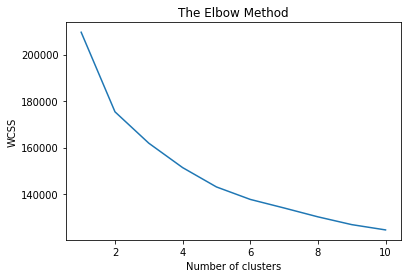

```python
wcss = []
for i in range(1, 11):
    kmeans = KMeans(n_clusters= i,random_state= 0)
    kmeans.fit(yesPotentiel.drop(["score","CLASS","score_comb"],axis=1))
    wcss.append(kmeans.inertia_)
plt.plot(range(1,11), wcss)
plt.title('The Elbow Method')
plt.xlabel('Number of clusters')
plt.ylabel('WCSS')
plt.show()
```

```python
kmeansYes = KMeans(n_clusters=4,random_state=0)
clustYes = kmeansYes.fit_predict(yesPotentiel.drop(["score","CLASS","score_comb"],axis=1))
yesPotentiel["cluster"] = clustYes
```

### Average Income :

```
Text(0.5,1,'Cluster 3')
```

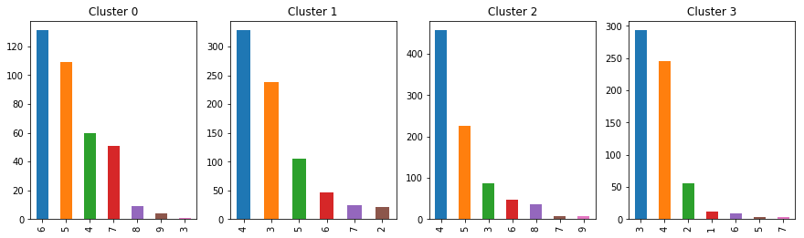

```python
fig, (ax1,ax2,ax3,ax4) = plt.subplots(1,4, figsize=(15,4))
yesPotentiel[yesPotentiel["cluster"] == 0]["Average_income"].value_counts().plot(kind="bar",ax=ax1)
ax1.set_title("Cluster 0")
yesPotentiel[yesPotentiel["cluster"] == 1]["Average_income"].value_counts().plot(kind="bar",ax=ax2)
ax2.set_title("Cluster 1")
yesPotentiel[yesPotentiel["cluster"] == 2]["Average_income"].value_counts().plot(kind="bar",ax=ax3)
ax3.set_title("Cluster 2")
yesPotentiel[yesPotentiel["cluster"] == 3]["Average_income"].value_counts().plot(kind="bar",ax=ax4)
ax4.set_title("Cluster 3")
```

Cluster 0 :

```
        6: 63 - 75%
        7: 76 - 88%
```

### High level education :

```
Text(0.5,1,'Cluster 3')
```

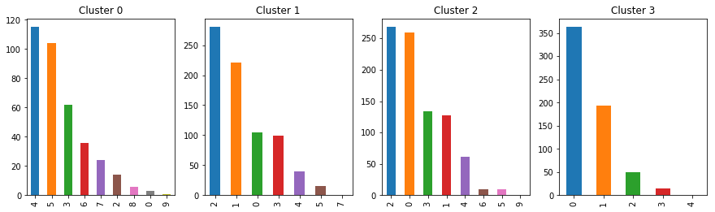

```python
fig, (ax1,ax2,ax3,ax4) = plt.subplots(1,4, figsize=(15,4))
yesPotentiel[yesPotentiel["cluster"] == 0]["High_level_education"].value_counts().plot(kind="bar",ax=ax1)
ax1.set_title("Cluster 0")
yesPotentiel[yesPotentiel["cluster"] == 1]["High_level_education"].value_counts().plot(kind="bar",ax=ax2)
ax2.set_title("Cluster 1")
yesPotentiel[yesPotentiel["cluster"] == 2]["High_level_education"].value_counts().plot(kind="bar",ax=ax3)
ax3.set_title("Cluster 2")
yesPotentiel[yesPotentiel["cluster"] == 3]["High_level_education"].value_counts().plot(kind="bar",ax=ax4)
ax4.set_title("Cluster 3")
```

Cluster 0 :

```
4: 37 - 49%
5: 50 - 62%
6: 63 - 75%
```

### High status :

```
Text(0.5,1,'Cluster 3')
```

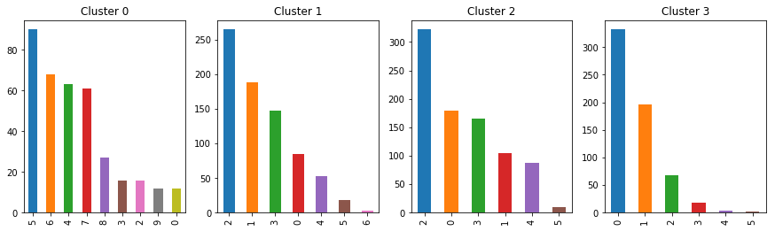

```python
fig, (ax1,ax2,ax3,ax4) = plt.subplots(1,4, figsize=(15,4))
yesPotentiel[yesPotentiel["cluster"] == 0]["High_status"].value_counts().plot(kind="bar",ax=ax1)
ax1.set_title("Cluster 0")
yesPotentiel[yesPotentiel["cluster"] == 1]["High_status"].value_counts().plot(kind="bar",ax=ax2)
ax2.set_title("Cluster 1")
yesPotentiel[yesPotentiel["cluster"] == 2]["High_status"].value_counts().plot(kind="bar",ax=ax3)
ax3.set_title("Cluster 2")
yesPotentiel[yesPotentiel["cluster"] == 3]["High_status"].value_counts().plot(kind="bar",ax=ax4)
ax4.set_title("Cluster 3")
```

Cluster 3 :

```
0: 0%
```

Cluster 0 :

```
4: 37 - 49%
5: 50 - 62%
6: 63 - 75%
7: 76 - 88%
```

### Household with children :

```
Text(0.5,1,'Cluster 3')
```

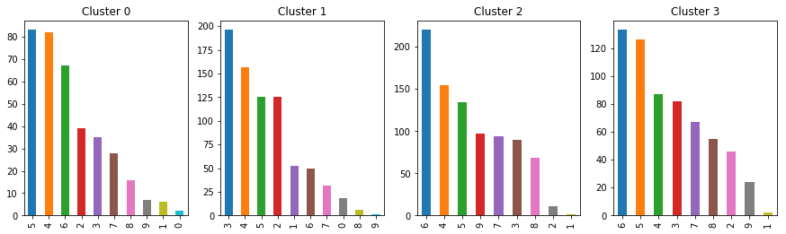

```python
fig, (ax1,ax2,ax3,ax4) = plt.subplots(1,4, figsize=(15,4))
yesPotentiel[yesPotentiel["cluster"] == 0]["Household_with_children"].value_counts().plot(kind="bar",ax=ax1)
ax1.set_title("Cluster 0")
yesPotentiel[yesPotentiel["cluster"] == 1]["Household_with_children"].value_counts().plot(kind="bar",ax=ax2)
ax2.set_title("Cluster 1")
yesPotentiel[yesPotentiel["cluster"] == 2]["Household_with_children"].value_counts().plot(kind="bar",ax=ax3)
ax3.set_title("Cluster 2")
yesPotentiel[yesPotentiel["cluster"] == 3]["Household_with_children"].value_counts().plot(kind="bar",ax=ax4)
ax4.set_title("Cluster 3")
```

Cluster 1 :

```
2: 11 - 23%
3: 24 - 36%
```

### Income < 30.000 :

```
Text(0.5,1,'Cluster 3')
```

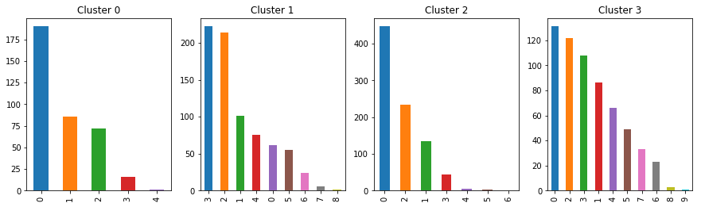

```python
fig, (ax1,ax2,ax3,ax4) = plt.subplots(1,4, figsize=(15,4))
yesPotentiel[yesPotentiel["cluster"] == 0]["Income_._30.000"].value_counts().plot(kind="bar",ax=ax1)
ax1.set_title("Cluster 0")
yesPotentiel[yesPotentiel["cluster"] == 1]["Income_._30.000"].value_counts().plot(kind="bar",ax=ax2)
ax2.set_title("Cluster 1")
yesPotentiel[yesPotentiel["cluster"] == 2]["Income_._30.000"].value_counts().plot(kind="bar",ax=ax3)
ax3.set_title("Cluster 2")
yesPotentiel[yesPotentiel["cluster"] == 3]["Income_._30.000"].value_counts().plot(kind="bar",ax=ax4)
ax4.set_title("Cluster 3")
```

Cluster 3 :

```
7: 76 - 88%
8: 89 - 99%
9: 100%
```

### Skilled labourers :

```
Text(0.5,1,'Cluster 3')
```

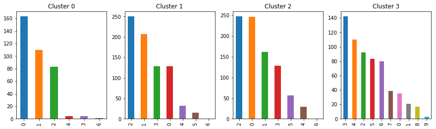

```python
fig, (ax1,ax2,ax3,ax4) = plt.subplots(1,4, figsize=(15,4))
yesPotentiel[yesPotentiel["cluster"] == 0]["Skilled_labourers"].value_counts().plot(kind="bar",ax=ax1)
ax1.set_title("Cluster 0")
yesPotentiel[yesPotentiel["cluster"] == 1]["Skilled_labourers"].value_counts().plot(kind="bar",ax=ax2)
ax2.set_title("Cluster 1")
yesPotentiel[yesPotentiel["cluster"] == 2]["Skilled_labourers"].value_counts().plot(kind="bar",ax=ax3)
ax3.set_title("Cluster 2")
yesPotentiel[yesPotentiel["cluster"] == 3]["Skilled_labourers"].value_counts().plot(kind="bar",ax=ax4)
ax4.set_title("Cluster 3")
```

Cluster 3 :

```
4: 37 - 49%
5: 50 - 62%
6: 63 - 75%
7: 76 - 88%
8: 89 - 99%
9: 100%
```

### Social class c

```
Text(0.5,1,'Cluster 3')
```

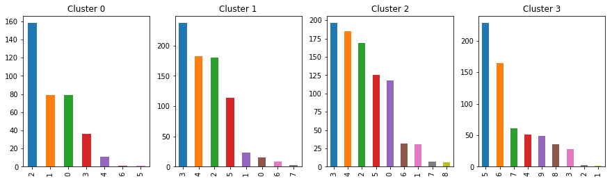

```python
fig, (ax1,ax2,ax3,ax4) = plt.subplots(1,4, figsize=(15,4))
yesPotentiel[yesPotentiel["cluster"] == 0]["Social_class_C"].value_counts().plot(kind="bar",ax=ax1)
ax1.set_title("Cluster 0")
yesPotentiel[yesPotentiel["cluster"] == 1]["Social_class_C"].value_counts().plot(kind="bar",ax=ax2)
ax2.set_title("Cluster 1")
yesPotentiel[yesPotentiel["cluster"] == 2]["Social_class_C"].value_counts().plot(kind="bar",ax=ax3)
ax3.set_title("Cluster 2")
yesPotentiel[yesPotentiel["cluster"] == 3]["Social_class_C"].value_counts().plot(kind="bar",ax=ax4)
ax4.set_title("Cluster 3")
```

Cluster 2 :

```
0:0%
```

### Customer Subtype :

```
Text(0.5,1,'Cluster 3')
```

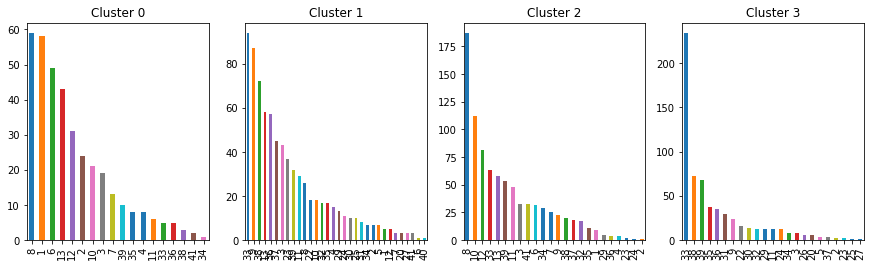

```python
fig, (ax1,ax2,ax3,ax4) = plt.subplots(1,4, figsize=(15,4))
data.iloc[yesPotentiel[yesPotentiel["cluster"] == 0].index,:]["Customer_Subtype_see_L0"].value_counts().plot(kind="bar",ax=ax1)
ax1.set_title("Cluster 0")
data.iloc[yesPotentiel[yesPotentiel["cluster"] == 1].index,:]["Customer_Subtype_see_L0"].value_counts().plot(kind="bar",ax=ax2)
ax2.set_title("Cluster 1")
data.iloc[yesPotentiel[yesPotentiel["cluster"] == 2].index,:]["Customer_Subtype_see_L0"].value_counts().plot(kind="bar",ax=ax3)
ax3.set_title("Cluster 2")
data.iloc[yesPotentiel[yesPotentiel["cluster"] == 3].index,:]["Customer_Subtype_see_L0"].value_counts().plot(kind="bar",ax=ax4)
ax4.set_title("Cluster 3")
```

Cluster 0 : 8,1,13

Cluster 1 : 33,38

Cluster 2 : 8,10,12

Cluster 3 : 33,38,39

### Segments :

#### Cluster 0 :

```
Average Income : 63%-88%
High level education : 37-75%
High status : 37-88%
Customer subtype : High Income, expensive child / Middle class families / Career and childcare
```

#### Cluster 1 :

```
Household with children : 11%-36%
Customer Subtype : Lower class large families / Traditional families
```

#### Cluster 2 :

```
Customer Subtype :  Middle class families / Stable family / Affluent young families
```

#### Cluster 3 :

```
High status: 0%
Income < 30.000 : 76%-100%
Skilled labourers : 37%-100%
Customer Subtype : Lower class large families / Traditional families / Large religous families
```